# Averaged CB28 and CB52 vs YEAR trends FV1

Marc Roddis

3/5/2020

In this document we repeat our analysis from our previous document except that we will use averaged PCB concentrations whereas we did not use averages previously. We will model our R code on the example code provided by Martin Sköld in “data.md”.

#### Creation of a dataset with LOQ/sqrt(2) substituted censored values and annual geometric means of PCB concentrations

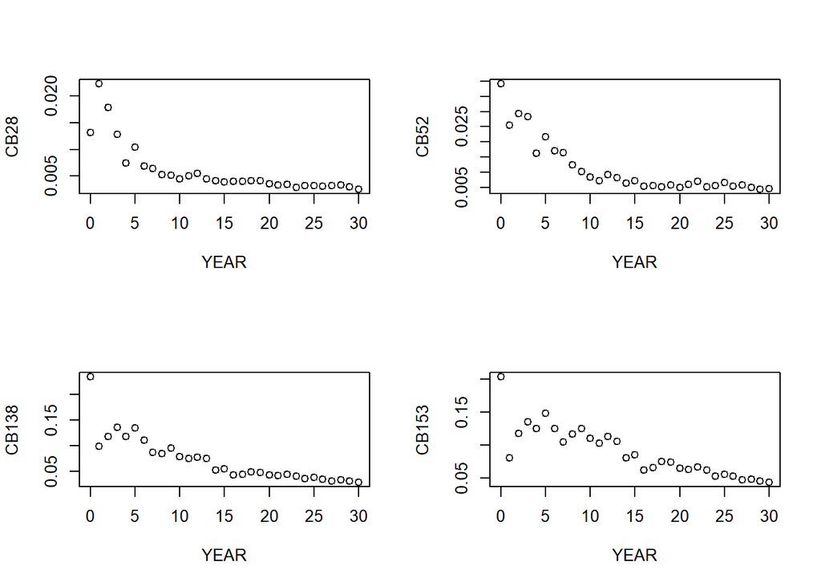

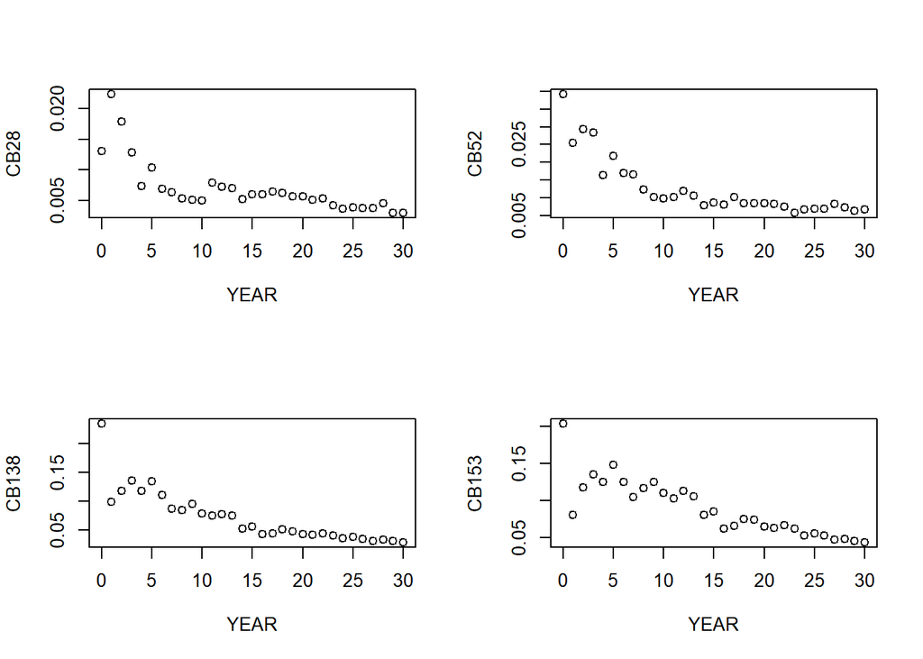

#### Repeating above analysis for various time periods

There are 40 and 77 observations for 1987 and 1988 respectively whereas there are at least 133 observations every year from 1989 onwards (this data is not displayed). We will now repeat the above analysis except that we will only include observations from 1989 onwards.

#### Using LOQ/sqrt(2) substituted censored values for data from 1989 onwards

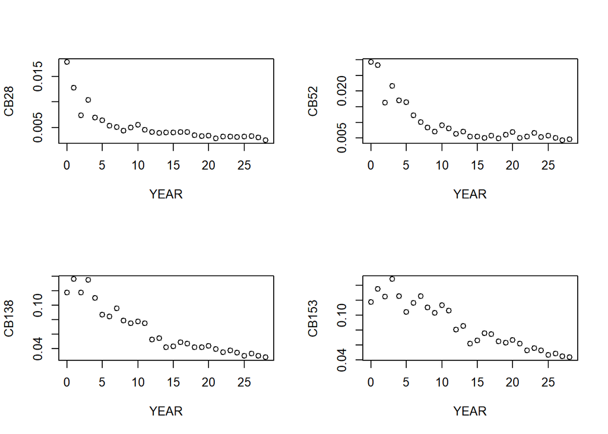

#### Using exclusion of censored values for data from 1989 onwards

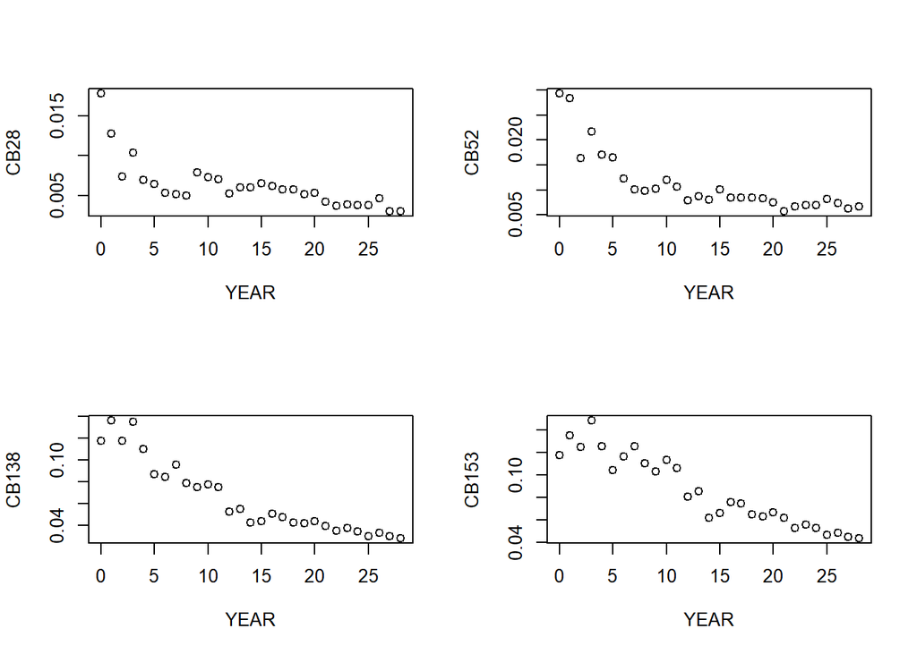

#### Intermediate (second) summary

As stated previously: starting from 1987 the adjusted R-squared values for CB28:CB180 for the fitted model after substitution using LOQ/sqrt(2) were (0.55, 0.64, 0.65, 0.65, 0.72, 0.75, 0.72). The corresponding values after exclusion of censored data were (0.53, 0.64, 0.68, 0.64, 0.72, 0.75, 0.71).

We see that the adjusted R-squared values for CB118:CB180 were higher when starting from 1989 than from 1987. However, the values from “exclusion” or “substitution by LOQ/sqrt(2)” of censored values were very similar.

We should remain alert to the fact that all of the above related to fitting linear models so it may not be relevant if such models are unsuitable.